# ab_search_chess

License Agreement - This software is provided under BSD2 license:  
Copyright © 2020 Denis Osipychev < osipychev at gmail dot com >  
Redistribution and use in source and binary forms, with or without modification, are permitted provided that the following conditions are met:

- 1. Redistributions of source code must retain the above copyright notice, this list of conditions and the following disclaimer.
- 2. Redistributions in binary form must reproduce the above copyright notice, this list of conditions and the following disclaimer in the documentation and/or other materials provided with the distribution.

THIS SOFTWARE IS PROVIDED BY THE COPYRIGHT HOLDERS AND CONTRIBUTORS "AS IS" AND ANY EXPRESS OR IMPLIED WARRANTIES, INCLUDING, BUT NOT LIMITED TO, THE IMPLIED WARRANTIES OF MERCHANTABILITY AND FITNESS FOR A PARTICULAR PURPOSE ARE DISCLAIMED. IN NO EVENT SHALL THE COPYRIGHT HOLDER OR CONTRIBUTORS BE LIABLE FOR ANY DIRECT, INDIRECT, INCIDENTAL, SPECIAL, EXEMPLARY, OR CONSEQUENTIAL DAMAGES (INCLUDING, BUT NOT LIMITED TO, PROCUREMENT OF SUBSTITUTE GOODS OR SERVICES; LOSS OF USE, DATA, OR PROFITS; OR BUSINESS INTERRUPTION) HOWEVER CAUSED AND ON ANY THEORY OF LIABILITY, WHETHER IN CONTRACT, STRICT LIABILITY, OR TORT (INCLUDING NEGLIGENCE OR OTHERWISE) ARISING IN ANY WAY OUT OF THE USE OF THIS SOFTWARE, EVEN IF ADVISED OF THE POSSIBILITY OF SUCH DAMAGE.

# Alpha-Beta Search for Chess Engine

Simple example of Alpha-Beta search in a two player game of Chess.

The game has gigantic state/action spaces. The discrete actions taken asynchronously make the game a good fit for utilizing tree-search methods.

However, the number of evaluations required is exponentially growing with the depth of the search. This does not allow finding an explicit solution and require evaluating the boards along the game. There are many strategies of evaluating the board.

Here, I show the simplest way evaluating so called 'material' of the board.

```python
import numpy as np
import chess
import chess.pgn
import copy
from random import shuffle

import matplotlib.pyplot as plt
```

Evaluation of the material on the board is just assigning certain values of the pieces.

The sum of all the pieces on the board would serve as a measure of the action success. Of course, the depth of the search is important here so you can avoid counterattacks. It is a simple, classic method of evaluation taught in chess schools.

```python
piece_cost = {
    'p' : -0.01,
    'r' : -0.05,
    'n' : -0.03,
    'b' : -0.03,
    'q' : -0.09,
    'k' : -0.90,
    'P' :  0.01,
    'R' :  0.05,
    'N' :  0.03,
    'B' :  0.03,
    'Q' :  0.09,
    'K' :  0.90
}

def evaluateBoard(board):
    totalSum = 0
    b_str = board.board_fen()
    for ch in b_str:
        totalSum += piece_cost.get(ch, 0)

    return totalSum
```

Recursive Alpha-Beta search truncates the decision tree by bounding the min/max values of the branches. This reduces the number of evaluations.

```python
n_eval = 0  # board evaluation counter

# Alpha-Beta search recursive function
def abeta(board, eval_fn, depth, alpha=-1, beta=1, maximizing=True, min_value=-1, max_value=1):
    global n_eval

    # evaluate the board
    if board.is_game_over():
        if board.result() == "1-0":
            return max_value
        elif board.result() == "0-1":
            return min_value
        else:
            return 0

    if (depth == 0):
        n_eval += 1
        return eval_fn(board)

    # reset the best value
    if (maximizing):
        bestValue = min_value
    else:
        bestValue = max_value

    # get all the available moves
    moves = list(board.legal_moves)
    shuffle(moves)

    # iterate over the moves
    for m in moves:
        candidate = board.copy()
        candidate.push(m)
        v = abeta(candidate, eval_fn, depth - 1, alpha, beta, not maximizing,
                                        max_value=max_value, min_value=min_value)

        # update the best value and the bounds
        if (maximizing):
            bestValue = max(bestValue, v)
            alpha = max(alpha, bestValue)
        else:
            bestValue = min(bestValue, v)
            beta = min(beta, bestValue)

        if (beta <= alpha):
            return bestValue

    return bestValue


def get_action(board, eval_fn, max_depth=2):

    bestMove = None
    bestValue = -1

    moves = list(board.legal_moves)
    shuffle(moves)

    for m in moves:
        candidate = board.copy()
        candidate.push(m)
        v = abeta(candidate, eval_fn, max_depth - 1, maximizing=False)
        if (v >= bestValue):
            bestValue = v
            bestMove = m

    return bestMove, bestValue
```

Let's test it with a single action selection run with the search depth of 5.

```python
# initialize new game
board = chess.Board()

# reset the evaluation counter
n_eval = 0

action, value = get_action(board, evaluateBoard, max_depth=5)
board.push(action)

print("The best move: %s, value of the future state: %0.2f, number of evaluations: %d."%(action, value, n_eval))

board
```

```
The best move: c2c3, value of the future state: 0.01, number of evaluations: 181098.
```

[figure not shown]

Nothing exciting yet.

The search went through over 180k states to find an action that guarantees an advantage over the opponent. It means that after 5 steps, the player would have an advantage in one pawn.

In a real game, this may not be a significant advantage without considering so called the "quality" of the position. This refers to having a better position on the board.

Now, let's compare the result of the alpha-beta search algorithm playing against itself with different depths.

```python
def ai1(board):
#     m, v = np.random.choice(list(board.legal_moves)), 0
    m, v = get_action(board, evaluateBoard, max_depth=3)
    return m, v

def ai2(board):
#     m, v = np.random.choice(list(board.legal_moves)), 0
    m, v = get_action(board, evaluateBoard, max_depth=2)
    return m, v
```

```python
def run_game(ai1, ai2):
    global n_eval

    board = chess.Board()

    white_stats = []
    black_stats = []
    move_count = 0
    max_moves = 100

    while move_count < max_moves:
        move_count += 1
        if board.turn:
            n_eval = 0

            move, value = ai1(board)
            board.push(move)

            white_stats.append([value, n_eval])
        else:
            candidate = board.mirror()

            n_eval = 0
            move, value = ai2(candidate)
            candidate.push(move)
            board = candidate.mirror()

            black_stats.append([value, n_eval])

        if board.is_game_over():
            break

    return board, [white_stats, black_stats]
```

```python
board, stats = run_game(ai1, ai2)
print(board.result())
board
```

```
1-0
```

[figure not shown]

It is a good sign because the average number of moves in professional players playing chess is 20-30 moves.

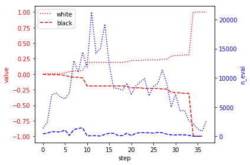

```python
v_w, n_w = zip(*stats[0])
v_b, n_b = zip(*stats[1])
fig, ax1 = plt.subplots()
ax1.set_xlabel('step')

ax1.plot(v_w,'r:')
ax1.plot(v_b,'r--')
ax1.legend(['white', 'black'])
ax1.set_ylabel('value', color='r')
ax1.tick_params(axis='y', labelcolor='r')

ax2 = ax1.twinx()
ax2.plot(n_w, 'b:')
ax2.plot(n_b, 'b--')
ax2.set_ylabel('n_eval', color='b')
ax2.tick_params(axis='y', labelcolor='b')

fig.tight_layout()
plt.show()
```

The larger depth provides a significant advantage sacrificing the larger number of evaluations.

The algorithm with smaller depth has no chance of winning because the opponent is always "one step ahead". You can see it in small statistics below.

```python
total_games = 10
white_wins = 0
black_wins = 0
draws = 0

for i in range(total_games):
    b, s = run_game(ai1, ai2)

    if b.result() == "1-0":
        white_wins += 1
    elif b.result() == "0-1":
        black_wins += 1
    else:
        draws +=1

    print("Games played: %d. White won: %d." % (i+1,white_wins), end="\r", flush=True)

print("ai1 wins: %0.1f%% (%d) , ai2 wins: %0.1f%% (%d), draws: %0.1f%% (%d)" %
      (100*white_wins/total_games, white_wins,
       100*black_wins/total_games, black_wins,
       100*draws/total_games, draws))
```

```
ai1 wins: 70.0% (7) , ai2 wins: 0.0% (0), draws: 30.0% (3)
```